# OTX2 case study — Fig 3f

Violin of log2(KD/control) RNA fold-change on day 2, for **4C-activated** genes vs an **expression-matched Random** control set, each split by whether the gene's promoter (TSS ± 2.5 kb) carries a 4C OTX2 peak.

Paper (two-sided Mann-Whitney U): 4C+ vs 4C- P = 2 × 10⁻⁵; Random+ vs Random- P = 0.8.

Paper: Wang et al. *Nat. Genet.* **57**, 2772-2784 (2025) 10.1038/s41588-025-02350-8

> **Upstream / preprocessing.** FASTQ → BAM → bigwig, MACS2 peak calling, Xia 2019 / Zou 2022 / Gifford 2013 downloads, and the one-off xlsx → TSV extractions are all documented in `preprocess.ipynb`. This notebook starts from the cached inputs under `/scratch/users/steorra/data/otx2/`.

## 1 · Setup

### RNA-seq FASTQ → DEG (not in preprocess.ipynb)

fig3d/fig3f consume the paper's DESeq2 DEG output (Supp Table S6). That workflow is RNA-seq-specific and outside `epione`'s epigenomics scope, so the recipe is kept inline here rather than in `preprocess.ipynb`.

```python
%%script false --no-raise-error
# =========================================================
# RNA-seq FASTQ -> gene counts -> DESeq2 DEG (Supp Table S6)
# =========================================================
# This block is specific to fig3d / fig3f (DEG-based analyses) — it is NOT
# part of epione's core scope (epione consumes bigwigs / peaks / TSVs),
# so it lives here instead of in preprocess.ipynb.
STAR --runThreadN 8 --runMode alignReads \
     --genomeDir /scratch/users/steorra/data/hg19/star_idx \
     --readFilesIn $FQDIR/${SAMPLE}_R1.fastq.gz $FQDIR/${SAMPLE}_R2.fastq.gz \
     --readFilesCommand zcat --outSAMtype BAM SortedByCoordinate \
     --outFileNamePrefix $BAMDIR/${SAMPLE}.
featureCounts -T 8 -p --countReadPairs \
     -a /scratch/users/steorra/data/hg19/gencode.v41lift37.annotation.gtf.gz \
     -o counts.tsv $BAMDIR/*.Aligned.sortedByCoord.out.bam
Rscript -e '
library(DESeq2)
counts <- as.matrix(read.table("counts.tsv", header=TRUE, row.names=1,
                                check.names=FALSE, skip=1)[,-(1:5)])
coldata <- data.frame(row.names = colnames(counts),
                      condition = factor(sub("_rep.*$", "", colnames(counts))))
dds <- DESeqDataSetFromMatrix(counts, coldata, ~ condition)
dds <- DESeq(dds)
res <- results(dds, contrast=c("condition","h_OTX2_KD_day2","h_OTX2_ctrl_day2"))
write.table(as.data.frame(res), "S6_D2_OTX2_KD_DEG.tsv", sep="\t", quote=FALSE)
'
```

```python
import os, pathlib, warnings
os.environ['PATH'] = '/scratch/users/steorra/env/omicdev/bin:' + os.environ.get('PATH', '')
warnings.filterwarnings('ignore', category=UserWarning)

import numpy as np
import pandas as pd
import matplotlib.pyplot as plt

import epione as epi
epi.pl.plot_set()

DATA         = pathlib.Path('/scratch/users/steorra/data/otx2')
OMIX         = DATA / 'OMIX006476'
ZOU          = DATA / 'GSE197265'
XIA          = DATA / 'GSE124718'
GIFFORD      = DATA / 'GSE61475'
SUPP_TABLES  = DATA / 'supp/supp_tables.xlsx'
GENCODE_GTF  = pathlib.Path('/scratch/users/steorra/data/hg19/gencode.v41lift37.annotation.gtf.gz')
```

[output not shown]

[output not shown]

## 2 · Paper-grade log2FC for every gene

Use DESeq2 values from Supp Table S6 (769 DEGs) where available, fall back to a median-of-ratios estimate from S4 batch-1 counts for the rest (Pearson r = 0.97 vs paper's DESeq2 on overlap).

```python
import re
s3 = pd.read_excel(SUPP_TABLES, sheet_name='Table S3_stage-activated genes', header=1)
s3.columns = [str(c).strip() for c in s3.columns]
col4c = next(c for c in s3.columns if '4-cell' in c.lower() or c.lower() == '4c')
activated_4c = set(s3[col4c].dropna().astype(str).str.strip()) - {'nan',''}

s6 = pd.read_excel(SUPP_TABLES, sheet_name='Table S6_DEG', header=None)
start = next(i for i,r in s6.iterrows() if isinstance(r[0],str) and 'D2-OTX2-KD-DEG' in r[0]) + 1
hdrs = [str(v).strip() for v in s6.iloc[start].values]
body, j = [], start + 1
while j < len(s6):
    v0 = s6.iloc[j, 0]
    if pd.isna(v0) or (isinstance(v0, str) and v0.endswith('DEG')): break
    body.append(s6.iloc[j].values); j += 1
seen = {}; uniq = []
for c in hdrs[:len(body[0])]:
    k = c if c not in ('nan','None','') else f'_drop{len(uniq)}'
    seen[k] = seen.get(k,0) + 1
    uniq.append(f'{k}_{seen[k]}' if seen[k] > 1 else k)
deg = pd.DataFrame(body, columns=uniq).loc[:, lambda d: ~d.columns.str.startswith('_drop')]
for c in ('baseMean','log2FoldChange','pvalue','padj'):
    deg[c] = pd.to_numeric(deg[c], errors='coerce')
deg_lfc  = dict(zip(deg['gene'].astype(str), deg['log2FoldChange']))
deg_base = dict(zip(deg['gene'].astype(str), deg['baseMean']))
```

```python
s4 = pd.read_excel(SUPP_TABLES, sheet_name='Table S4_OTX2 KD_RNA count', header=2)
s4.columns = [str(c).strip() for c in s4.columns]
def _b1(c, pfx):
    m = re.search(r'_rep[12]_(\d[A-Z]\d+)_', c)
    return bool(m) and m.group(1).startswith(pfx)
ctrl = [c for c in s4.columns if 'ctrl_day2' in c and _b1(c, '4C')]
kd   = [c for c in s4.columns if 'KD_day2'   in c and _b1(c, '4K') and 'rescue' not in c]
ct = s4[['gene']+ctrl+kd].copy()
for c in ctrl+kd: ct[c] = pd.to_numeric(ct[c], errors='coerce').fillna(0)
mat = ct[ctrl+kd].values.astype(np.float64); logm = np.log(mat + 1e-9)
geo = np.where(np.all(mat>0,axis=1), np.mean(np.where(mat>0,logm,np.nan),axis=1), np.nan)
mask = ~np.isnan(geo)
sf = np.exp(np.median(logm[mask] - geo[mask][:,None], axis=0))
nrm = mat / sf[None,:]
cm = nrm[:, :len(ctrl)].mean(1); km = nrm[:, len(ctrl):].mean(1)
ct['baseMean'] = (cm + km) / 2
ct['my_lfc']   = np.log2((km + 1) / (cm + 1))
ct = ct[ct['baseMean'] > 5]
my_lfc  = dict(zip(ct['gene'].astype(str), ct['my_lfc']))
my_base = dict(zip(ct['gene'].astype(str), ct['baseMean']))
def _lfc(g):  return deg_lfc.get(g,  my_lfc.get(g))
def _base(g): return deg_base.get(g, my_base.get(g))
print(f'genes with baseMean>5: {len(ct)}')
```

```
genes with baseMean>5: 12470
```

## 3 · Expression-matched Random set via `epi.utils.expression_matched_sample`

Decile-bin matching on `baseMean` of 4C-activated genes; Random ends up ~same size as the activated set. Without expression matching the Random +/- p-value drops to 0.05, far from the paper's 0.8.

```python
expressed = set(ct['gene'].astype(str))
act_pool = [(g, _base(g)) for g in activated_4c if g in expressed]
pool     = [(g, _base(g)) for g in expressed if g not in activated_4c]
# Drop any with missing baseMean (rare; DEG table occasionally has NaN)
act_pool = [(g, b) for g, b in act_pool if b is not None and np.isfinite(b)]
pool     = [(g, b) for g, b in pool     if b is not None and np.isfinite(b)]

random_genes = set(epi.utils.expression_matched_sample(
    np.array([b for _, b in act_pool]),
    np.array([b for _, b in pool]),
    [g for g, _ in pool],
    n_bins=10, seed=0,
))
print(f'Random (expression-matched): {len(random_genes)}')
```

```
Random (expression-matched): 150
```

## 4 · Label each gene by OTX2 promoter binding (TSS ± 2.5 kb)

Uses Supp Table S7 peaks + GENCODE TSSs.

```python
gtf = epi.utils.get_gene_annotation(str(GENCODE_GTF))
gtf['tss'] = np.where(gtf['strand'] == '+', gtf['start'], gtf['end'])
gene2loc = gtf.drop_duplicates('gene_name').set_index('gene_name')[['chrom','tss']]

peaks_bed = pd.read_csv(OMIX / 'h_OTX2_day2_CUTRUN_rep12_peaks.bed',
                        sep='\t', header=None,
                        names=['chrom','start','end','name','score'])
peaks_by_chrom = {c: g[['start','end']].astype(int).values
                    for c, g in peaks_bed.groupby('chrom')}

def _bound(g):
    if g not in gene2loc.index: return None
    c, t = gene2loc.loc[g]
    arr = peaks_by_chrom.get(c)
    if arr is None: return False
    return bool(((arr[:,0] < t+2500) & (arr[:,1] > t-2500)).any())

def _split(genes):
    plus, minus = [], []
    for g in genes:
        v = _lfc(g); pb = _bound(g)
        if v is None or pb is None: continue
        (plus if pb else minus).append(v)
    return np.asarray(plus), np.asarray(minus)

p4, n4 = _split(activated_4c)
pr, nr = _split(random_genes)
print(f'4C: +{len(p4)} / -{len(n4)}   Random: +{len(pr)} / -{len(nr)}')
```

```
4C: +67 / -59   Random: +47 / -94
```

## 5 · Mann-Whitney U + paper-style violin

(Uses matplotlib directly — the plot is too bespoke for a generic helper.)

```
4C + vs -:   P = 0.0026  (paper 2e-5)
Rand + vs -: P = 0.24  (paper 0.8)
```

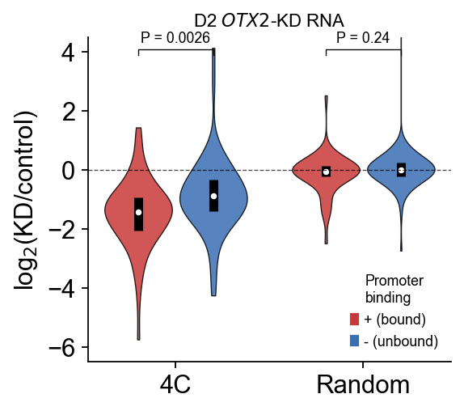

```python
from scipy.stats import mannwhitneyu
from matplotlib.patches import Patch

P_4c   = mannwhitneyu(p4, n4, alternative='two-sided').pvalue
P_rand = mannwhitneyu(pr, nr, alternative='two-sided').pvalue
print(f'4C + vs -:   P = {P_4c:.2g}  (paper 2e-5)')
print(f'Rand + vs -: P = {P_rand:.2g}  (paper 0.8)')

fig, ax = plt.subplots(figsize=(3.6, 3.3))
data = [p4, n4, pr, nr]; positions = [1, 1.8, 3, 3.8]
cols = ['#C93838', '#3A6EB3'] * 2
parts = ax.violinplot(data, positions=positions, widths=0.72,
                        showmeans=False, showextrema=False)
for pc, col in zip(parts['bodies'], cols):
    pc.set_facecolor(col); pc.set_edgecolor('black'); pc.set_alpha(0.85); pc.set_linewidth(0.6)
for pos, vals in zip(positions, data):
    q1, med, q3 = np.percentile(vals, [25, 50, 75])
    ax.vlines(pos, q1, q3, color='black', lw=5)
    ax.plot(pos, med, 'o', color='white', ms=4, mec='black', mew=0.6)
ax.axhline(0, ls='--', color='black', lw=0.6, alpha=0.7)
ax.set_xticks([1.4, 3.4]); ax.set_xticklabels(['4C', 'Random'])
ax.set_ylabel(r'log$_2$(KD/control)'); ax.set_title(r'D2 $OTX2$-KD RNA', fontsize=10)
ax.spines[['top','right']].set_visible(False); ax.set_ylim(-6.5, 4.5)
for (x0,x1), pv, y in [((1,1.8),P_4c,4.1),((3,3.8),P_rand,4.1)]:
    ax.plot([x0,x0,x1,x1],[y-0.2,y,y,y-0.2],'k-',lw=0.6)
    s = f'P = {pv:.0e}' if pv < 1e-3 else f'P = {pv:.2g}'
    ax.text((x0+x1)/2, y+0.1, s, ha='center', va='bottom', fontsize=8)
ax.legend(handles=[Patch(color='#C93838',label='+ (bound)'),
                     Patch(color='#3A6EB3',label='- (unbound)')],
           fontsize=8, title='Promoter\nbinding', title_fontsize=8,
           loc='lower right', frameon=False)
plt.show()
```